# Iranian Churn: A Comparative Analysis of Regularization and Support Vector Models for Customer Value and Churn Prediction

Joanne Musa

April 2025

# 1 INTRODUCTION

```r
#setwd("/Users/joannmusa/Desktop")

churn <- read.csv("https://jmusa3.github.io/jmusa/Customer_Churn.csv")


churn <- churn %>%
  rename(Call.Failure = `Call..Failure`,
         Subscription.Length = `Subscription..Length`,
         Charge.Amount = `Charge..Amount`)

# Rename the column
churn <- rename(churn, Frequency.of.Use = Frequency.of.use)
churn <- rename(churn, Complaints = Complains)
#head(churn)
```

The Iranian Churn Dataset, available from the UCI Machine Learning Repository, comprises data collected over 12 months from an Iranian telecom company’s database. It contains 3,150 instances, each representing a customer, with 13 attributes detailing various aspects of customer behavior and demographics.

Summary of Variables:

[output not shown]

These variables provide insights into customer behaviors, service usage patterns, and demographic information, facilitating analyses aimed at understanding and predicting customer churn.

There are no missing values in this data set.

# 2 EDA

## 2.1 Distribution of Individual Features

Understanding the distribution of individual features within the Iranian Churn Dataset is crucial for identifying patterns and insights related to customer behavior and churn tendencies. By analyzing the distribution of these features, significant trends can be visualized, such as the relationship between service usage patterns and customer retention, the impact of demographic factors on churn rates, and the effectiveness of different tariff plans. Such insights are instrumental in developing targeted strategies to enhance customer satisfaction and reduce churn.

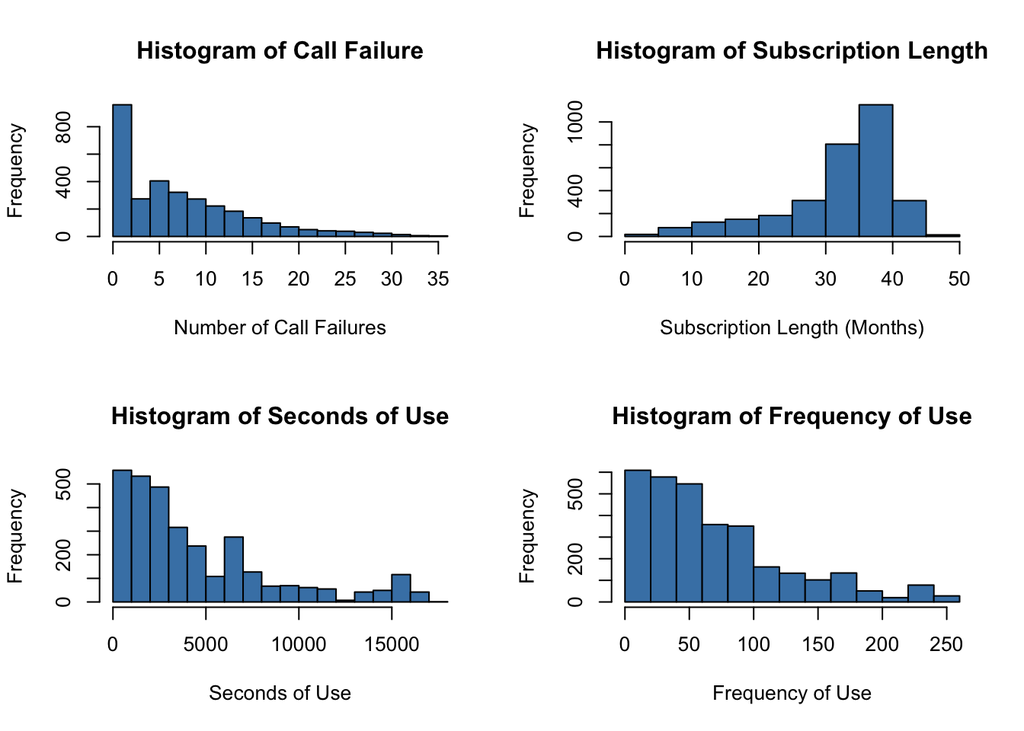

```r
# Set up a 2x2 plotting area
par(mfrow = c(2, 2))

# Histogram for Call Failure
hist(churn$Call.Failure,
     main = "Histogram of Call Failure",
     xlab = "Number of Call Failures",
     col = "steelblue")

# Histogram for Subscription Length
hist(churn$Subscription.Length,
     main = "Histogram of Subscription Length",
     xlab = "Subscription Length (Months)",
     col = "steelblue")

# Histogram for Seconds of Use
hist(churn$Seconds.of.Use,
     main = "Histogram of Seconds of Use",
     xlab = "Seconds of Use",
     col = "steelblue")

# Histogram for Frequency of Use
hist(churn$Frequency.of.Use,
     main = "Histogram of Frequency of Use",
     xlab = "Frequency of Use",
     col = "steelblue")
```

Figure A. Histograms of Call Failure, Subscription Length, Seconds of Use, and Frequency of Use.

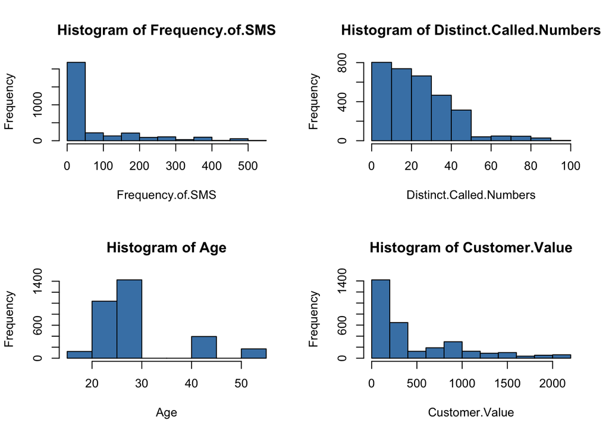

```r
# Set up a 2x2 plotting area
par(mfrow = c(2, 2))

# Histogram for Frequency.of.SMS
hist(churn$Frequency.of.SMS,
     main = "Histogram of Frequency.of.SMS",
     xlab = "Frequency.of.SMS",
     col = "steelblue",
     border = "black")

# Histogram for Distinct.Called.Numbers
hist(churn$Distinct.Called.Numbers,
     main = "Histogram of Distinct.Called.Numbers",
     xlab = "Distinct.Called.Numbers",
     col = "steelblue",
     border = "black")

# Histogram for Age
hist(churn$Age,
     main = "Histogram of Age",
     xlab = "Age",
     col = "steelblue",
     border = "black")

# Histogram for Customer.Value
hist(churn$Customer.Value,
     main = "Histogram of Customer.Value",
     xlab = "Customer.Value",
     col = "steelblue",
     border = "black")
```

```r
# Reset to default plotting area
par(mfrow = c(1, 1))
```

Figure B. Histograms of Frequency of SMS, Distinct Called Numbers, Age, and Customer Value.

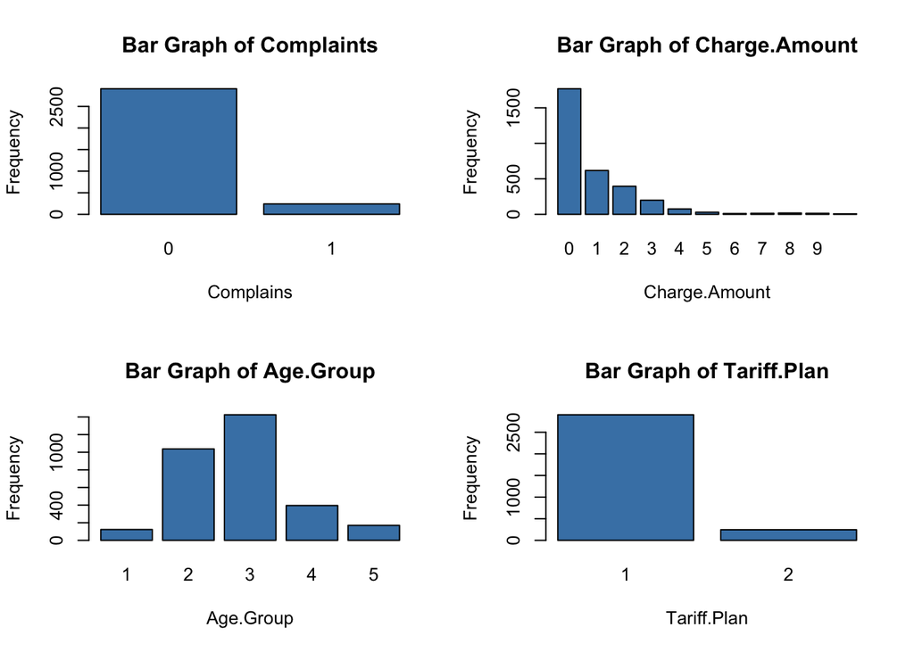

```r
# Set up a 2x2 plotting area
par(mfrow = c(2, 2))

# Bar graph for Complains
barplot(table(churn$Complaints),
        main = "Bar Graph of Complaints",
        xlab = "Complains",
        ylab = "Frequency",
        col = "steelblue",
        border = "black")

# Bar graph for Charge.Amount
barplot(table(churn$Charge.Amount),
        main = "Bar Graph of Charge.Amount",
        xlab = "Charge.Amount",
        ylab = "Frequency",
        col = "steelblue",
        border = "black")

# Bar graph for Age.Group
barplot(table(churn$Age.Group),
        main = "Bar Graph of Age.Group",
        xlab = "Age.Group",
        ylab = "Frequency",
        col = "steelblue",
        border = "black")

# Bar graph for Tariff.Plan
barplot(table(churn$Tariff.Plan),
        main = "Bar Graph of Tariff.Plan",
        xlab = "Tariff.Plan",
        ylab = "Frequency",
        col = "steelblue",
        border = "black")
```

Figure C. Bar charts of Complaints, Charge Amount, Age Group, and Tariff Plan.

A new feature named Charge.Level is created using Charge.Amount. Any Charge.Amount between 0 and 2 is “low” indicated by a Charge.Level of “0”. Any Charge.Amount between 3 and 6 is “medium” indicated by a Charge.Level of “1”. Any Charge.Amount between 7 and 9 is “high” indicated by a Charge.Level of “2”.

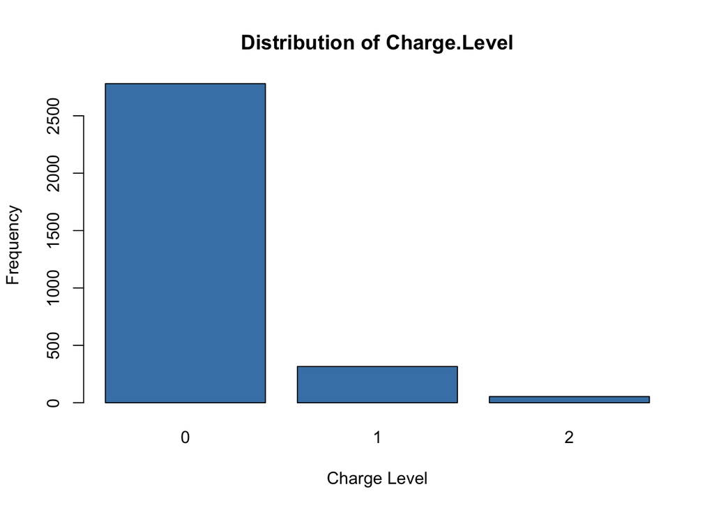

```r
# Convert Charge.Amount to numeric (if not already)
churn$Charge.Amount <- as.numeric(churn$Charge.Amount)

# Create Charge.Level based on Charge.Amount
churn <- churn %>%
  mutate(Charge.Level = case_when(
    Charge.Amount >= 0 & Charge.Amount <= 2 ~ "0",
    Charge.Amount > 2 & Charge.Amount <= 6 ~ "1",
    Charge.Amount > 6 & Charge.Amount <= 12 ~ "2",
    TRUE ~ NA_character_
  ))



# Remove rows with NA in Charge.Level
churn <- churn %>%
  filter(!is.na(Charge.Level))

# Create a frequency table for Charge.Level
charge_level_counts <- table(churn$Charge.Level)

# Generate the bar chart
barplot(charge_level_counts,
        main = "Distribution of Charge.Level",
        xlab = "Charge Level",
        ylab = "Frequency",
        col = "steelblue",
        border = "black")
```

Figure D. Bar Chart of engineered feature, Charge Level.

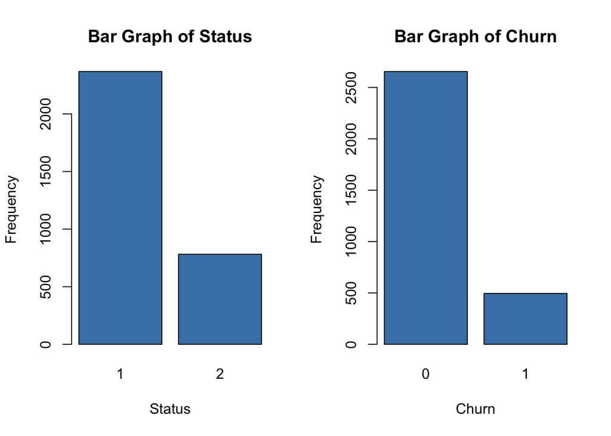

```r
# Set up a 2x1 plotting area
par(mfrow = c(1, 2))

# Bar graph for Status
barplot(table(churn$Status),
        main = "Bar Graph of Status",
        xlab = "Status",
        ylab = "Frequency",
        col = "steelblue",
        border = "black")

# Bar graph for Churn
barplot(table(churn$Churn),
        main = "Bar Graph of Churn",
        xlab = "Churn",
        ylab = "Frequency",
        col = "steelblue",
        border = "black")
```

```r
# Reset to default plotting area
par(mfrow = c(1, 1))
```

Figure E. Bar chart of Status and Churn.

## 2.2 Relationship between Features

Examining relationships between continuous variables using scatterplots and a correlation matrix provides a comprehensive approach to understanding associations. Scatterplots visually reveal how two continuous variables interact, allowing us to identify trends, correlations, and potential outliers. Meanwhile, a correlation matrix quantifies the strength and direction of relationships between multiple variables at once, helping to pinpoint which pairs are strongly correlated. Together, scatterplots and a correlation matrix offer valuable insights into the underlying patterns in the data, guiding further statistical analysis and model selection. In addition, examining relationships between categorical variables using mosaic plots reveal potential association between features.

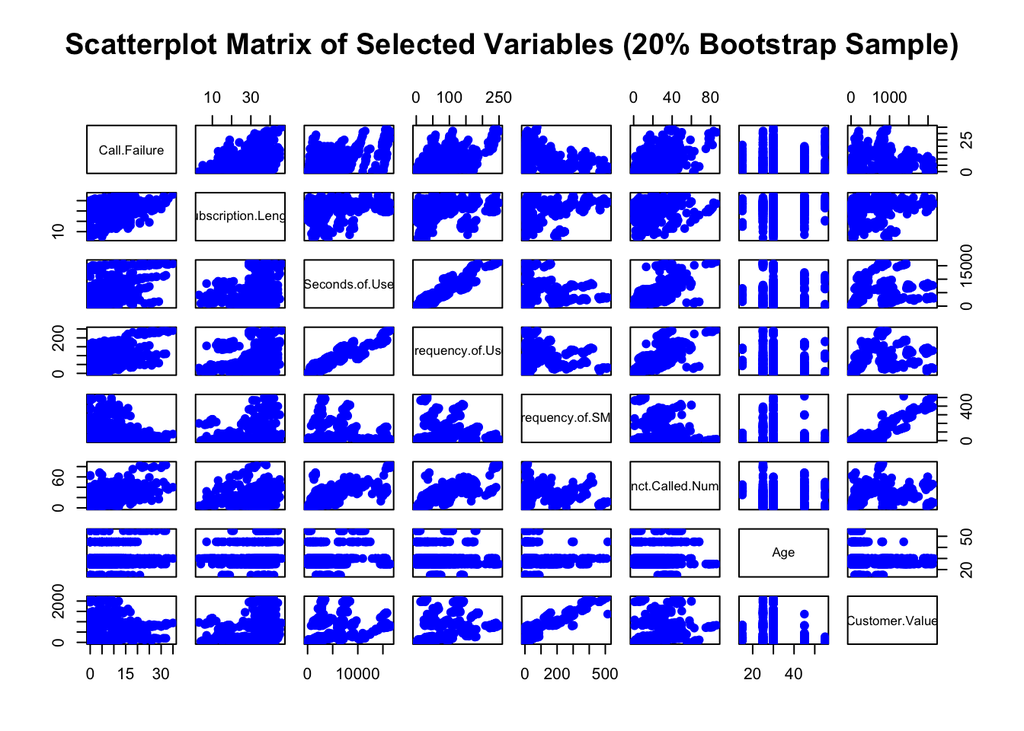

```r
# Set seed for reproducibility
set.seed(123)

# Calculate 20% of the dataset size
sample_size <- floor(0.20 * nrow(churn))

# Generate bootstrap sample indices
bootstrap_indices <- sample(seq_len(nrow(churn)), size = sample_size, replace = TRUE)

# Create bootstrap sample
bootstrap_sample <- churn[bootstrap_indices, ]


# Select relevant columns
selected_vars <- bootstrap_sample[, c("Call.Failure", "Subscription.Length", "Seconds.of.Use",
                                      "Frequency.of.Use", "Frequency.of.SMS", "Distinct.Called.Numbers", "Age",
                                      "Customer.Value")]

# Create scatterplot matrix
pairs(selected_vars,
      main = "Scatterplot Matrix of Selected Variables (20% Bootstrap Sample)",
      pch = 19,  # Solid circle for points
      col = "blue")  # Color of points
```

Correlation is used to further examine strength and direction of pairwise relationships.

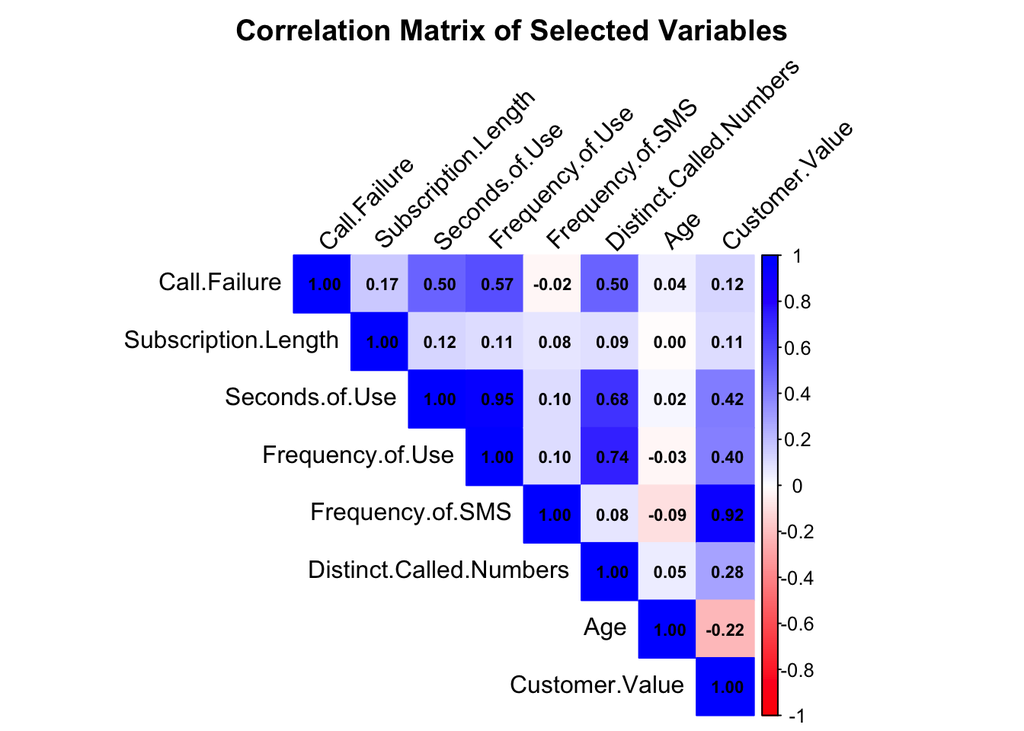

```r
# Select relevant columns
selected_vars <- churn[, c("Call.Failure", "Subscription.Length", "Seconds.of.Use",
                           "Frequency.of.Use", "Frequency.of.SMS", "Distinct.Called.Numbers", "Age",
                           "Customer.Value")]

# Compute correlation matrix
cor_matrix <- cor(selected_vars, use = "complete.obs", method = "pearson")



# Visualize the correlation matrix with adjusted top margin
corrplot(cor_matrix, method = "color", type = "upper",
         tl.col = "black", tl.srt = 45,
         addCoef.col = "black", number.cex = 0.7,
         col = colorRampPalette(c("red", "white", "blue"))(200),
         main = "Correlation Matrix of Selected Variables",
         mar = c(0, 0, 2, 0))  # Adjust the top margin here
```

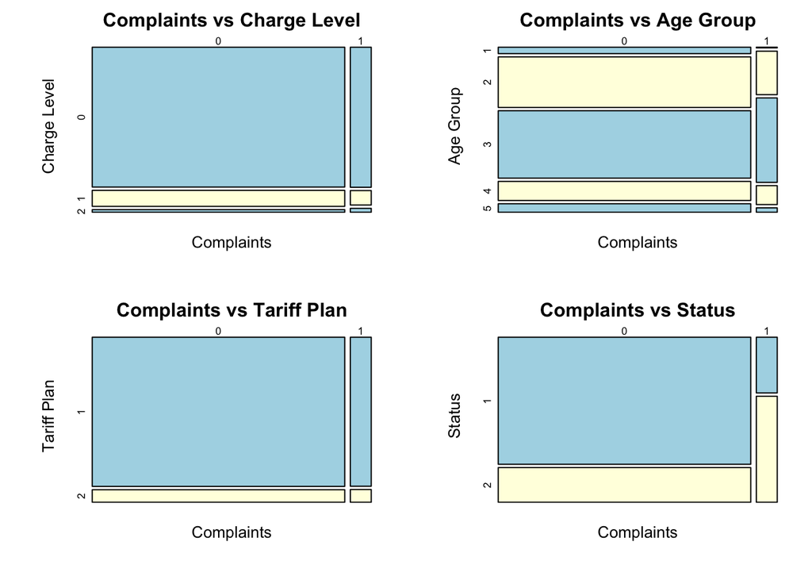

```r
# Convert variables to factors if they are not already
churn$Complaints <- as.factor(churn$Complaints)
churn$Charge.Amount <- as.factor(churn$Charge.Amount)
churn$Age.Group <- as.factor(churn$Age.Group)
churn$Tariff.Plan <- as.factor(churn$Tariff.Plan)
churn$Status <- as.factor(churn$Status)
churn$Churn <- as.factor(churn$Churn)



par(mfrow = c(2, 2), mar = c(4, 4, 2, 1))

# Mosaic plot for Complaints vs Charge.Level
mosaicplot(table(churn$Complaints, churn$Charge.Level),
           main = "Complaints vs Charge Level",
           xlab = "Complaints", ylab = "Charge Level",
           col = c("lightblue", "lightyellow"))

# Mosaic plot for Complaints vs Age.Group
mosaicplot(table(churn$Complaints, churn$Age.Group),
           main = "Complaints vs Age Group",
           xlab = "Complaints", ylab = "Age Group",
           col = c("lightblue", "lightyellow"))

# Mosaic plot for Complaints vs Tariff.Plan
mosaicplot(table(churn$Complaints, churn$Tariff.Plan),
           main = "Complaints vs Tariff Plan",
           xlab = "Complaints", ylab = "Tariff Plan",
           col = c("lightblue", "lightyellow"))

# Mosaic plot for Complaints vs Status
mosaicplot(table(churn$Complaints, churn$Status),
           main = "Complaints vs Status",
           xlab = "Complaints", ylab = "Status",
           col = c("lightblue", "lightyellow"))
```

Figure H. There appears to be a strong association between complaints and charge level, status, and age group. The less customers spend the more they complain. The middle age group tend to complain more. Customers who complained more tend to be inactive customers.

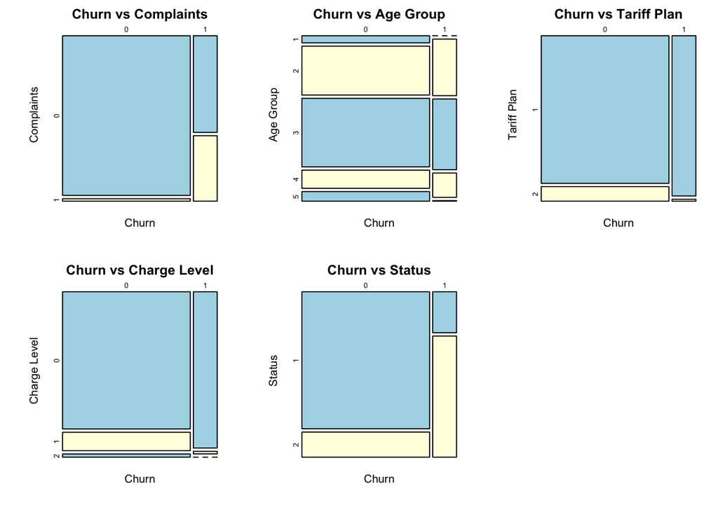

```r
par(mfrow = c(2, 3), mar = c(4, 4, 2, 1))

# Mosaic plot for Churn vs Complaints
mosaicplot(table(churn$Churn, churn$Complaints),
           main = "Churn vs Complaints",
           xlab = "Churn", ylab = "Complaints",
           col = c("lightblue", "lightyellow"))

# Mosaic plot for Churn vs Age.Group
mosaicplot(table(churn$Churn, churn$Age.Group),
           main = "Churn vs Age Group",
           xlab = "Churn", ylab = "Age Group",
           col = c("lightblue", "lightyellow"))

# Mosaic plot for Churn vs Tariff.Plan
mosaicplot(table(churn$Churn, churn$Tariff.Plan),
           main = "Churn vs Tariff Plan",
           xlab = "Churn", ylab = "Tariff Plan",
           col = c("lightblue", "lightyellow"))

# Mosaic plot for Churn vs Charge.Level
mosaicplot(table(churn$Churn, churn$Charge.Level),
           main = "Churn vs Charge Level",
           xlab = "Churn", ylab = "Charge Level",
           col = c("lightblue", "lightyellow"))

# Mosaic plot for Churn vs Status
mosaicplot(table(churn$Churn, churn$Status),
           main = "Churn vs Status",
           xlab = "Churn", ylab = "Status",
           col = c("lightblue", "lightyellow"))
```

Figure I. Churn is associated with complaints, age group, tariff plan, charge level, and status. Customers who complain tend to have higher churn rates. The youngest and oldest age groups tend to have lower churn rates, while the three middles age groups do tend to have higher churn rates. Those customers on pay as you go plans have higher churn rates. Customers who have the lowest charge level tend have higher churn rates. Customers who are inactive tend to have a much higher churn rate.

## 2.3 FEATURE ENGINEER

Principal Component Analysis (PCA) is a powerful unsupervised technique for data analysis. PCA reduces the dimensionality of data by transforming it into uncorrelated components, preserving the most variance.

```r
# Subset the data to include only the relevant features
churn_subset <- churn[, c("Subscription.Length", "Seconds.of.Use",
                          "Frequency.of.Use", "Frequency.of.SMS", "Distinct.Called.Numbers")]

# Apply log transformation (adding 1 to avoid log(0) issues)
churn_log <- log(churn_subset + 1)

# Standardize the data (mean = 0, standard deviation = 1)
churn_scaled <- scale(churn_log)

# Perform PCA
pca_result <- prcomp(churn_scaled, center = TRUE, scale. = TRUE)

# Create a new dataframe with the first three principal components
pca_data <- data.frame(pca_result$x[, 1:3])  # Extract PCA1, PCA2, PCA3

# Rename the columns based on the biggest contributors to each principal component
# Based on the loadings, rename the components:
# PCA1 is mainly influenced by Seconds.of.Use, Frequency.of.Use, and Distinct.Called.Numbers
# PCA2 is influenced by Subscription.Length
# PCA3 is influenced by Frequency.of.SMS
colnames(pca_data) <- c("Usage.Frequency.PC", "Subscription.Length.PC", "Frequency.SMS.PC")

# Combine PCA components with the original dataset (excluding specified columns)
churn.pca <- cbind(churn, pca_data)

# Drop only the specified columns (Subscription.Length, Seconds.of.Use, Frequency.of.Use, Frequency.of.SMS)
churn.pca <- churn.pca[, !colnames(churn.pca) %in% c("Subscription.Length", "Seconds.of.Use", "Frequency.of.Use", "Frequency.of.SMS")]

# Display the PCA loadings (i.e., the importance of each original feature for each principal component)
loadings <- pca_result$rotation
print(loadings)
```

```
                                PC1         PC2        PC3           PC4
Subscription.Length     -0.05848099  0.98284190 -0.1547905  0.0777530016
Seconds.of.Use          -0.54588391 -0.06265314  0.1916816  0.5858841014
Frequency.of.Use        -0.55714122  0.00195359  0.1882903  0.1788010408
Frequency.of.SMS        -0.31210273 -0.16586251 -0.9354525  0.0005419976
Distinct.Called.Numbers -0.53923676  0.05081532  0.1696274 -0.7865902266
                                 PC5
Subscription.Length     -0.024416336
Seconds.of.Use          -0.563988755
Frequency.of.Use         0.788775498
Frequency.of.SMS         0.003142192
Distinct.Called.Numbers -0.243195121
```

```r
# Display PCA summary and importance
pca_summary <- summary(pca_result)
importance_df <- as.data.frame(pca_summary$importance)
importance_df <- t(importance_df)
colnames(importance_df) <- c("Standard Deviation", "Proportion of Variance", "Cumulative Proportion")

# Print the PCA summary with kable
print(kable(importance_df,
            caption = "PCA Summary: Importance of Components"))
```

```
Table: PCA Summary: Importance of Components

|    | Standard Deviation| Proportion of Variance| Cumulative Proportion|
|:---|------------------:|----------------------:|---------------------:|
|PC1 |          1.7323840|                0.60023|               0.60023|
|PC2 |          1.0021388|                0.20086|               0.80109|
|PC3 |          0.8815434|                0.15542|               0.95651|
|PC4 |          0.3999742|                0.03200|               0.98851|
|PC5 |          0.2397190|                0.01149|               1.00000|
```

```r
#head(churn.pca)
```

Table 1. The PCA analysis reduced the dimensionality of the data by creating three principal components, capturing the most significant variance. These components simplify the data while retaining essential information for further analysis.

# 3 LINEAR REGRESSION

## 3.1 Regularized Linear Regression

In analyzing customer churn data with PCA features to predict customer value, regularized regression techniques such as Lasso, Ridge, and Elastic Net are employed to enhance predictive accuracy and model interpretability. Lasso Regression (Least Absolute Shrinkage and Selection Operator) introduces an L1 penalty, encouraging sparsity by shrinking some coefficients to zero, effectively performing variable selection. Ridge Regression, on the other hand, applies an L2 penalty, which shrinks coefficients uniformly, particularly useful when dealing with multicollinearity among predictors. Elastic Net Regression combines both L1 and L2 penalties, offering a balanced approach that leverages the strengths of Lasso and Ridge, making it especially effective in scenarios with highly correlated features or when the number of predictors exceeds the number of observations. Utilizing these methods in churn analysis allows for the identification of key factors influencing customer retention, leading to more targeted and effective business strategies.

### 3.1.1 Lasso

Lasso (Least Absolute Shrinkage and Selection Operator) regression is a regularization technique that enhances the prediction accuracy and interpretability of statistical models by adding a penalty equal to the absolute value of the magnitude of coefficients. This method performs variable selection and regularization simultaneously, producing sparse models where some coefficients are exactly zero.

```r
# Define response variable
response <- churn.pca$Customer.Value

# Define matrix of predictor variables
predictors <- data.matrix(churn.pca[, setdiff(names(churn.pca), "Customer.Value")])


set.seed(123)  # For reproducibility
train_index <- createDataPartition(response, p = 0.8, list = FALSE)
x_train <- predictors[train_index, ]
y_train <- response[train_index]
x_test <- predictors[-train_index, ]
y_test <- response[-train_index]

# Perform cross-validation to find the optimal lambda
cv_model <- cv.glmnet(x_train, y_train, alpha = 1, standardize = TRUE)

# Extract the best lambda value
best_lambda <- cv_model$lambda.min

# Make predictions on the test set
predictions <- predict(cv_model, s = best_lambda, newx = x_test)

# MSE Lasso
mse_lasso <- mean((predictions - y_test)^2)
#print(paste("Mean Squared Error on Test Set:", round(mse_lasso, 2)))

# Extract coefficients as a matrix
coef_matrix <- as.matrix(coef(cv_model, s = best_lambda))

# Convert the matrix to a data frame
coef_df <- data.frame(
  Feature = rownames(coef_matrix),
  Coefficient = coef_matrix[, 1],
  row.names = NULL
)

# Filter out features with zero coefficients
non_zero_coef_df <- subset(coef_df, Coefficient != 0)

# Display the table using kable
non_zero_coef_df %>%
  kable(
    caption = "Non-Zero Coefficients from Lasso Regression Model",
    col.names = c("Feature", "Coefficient"),
    align = "l"
  ) %>%
  kable_styling(bootstrap_options = c("striped", "hover", "condensed"), full_width = FALSE)
```

Non-Zero Coefficients from Lasso Regression Model

| Feature | Coefficient |
| --- | --- |
| (Intercept) | 1046.920173 |
| Call.Failure | -9.173692 |
| Complaints | 13.788723 |
| Charge.Amount | -15.871576 |
| Distinct.Called.Numbers | 4.409795 |
| Age.Group | 71.081363 |
| Tariff.Plan | 41.855182 |
| Status | -274.827194 |
| Age | -21.332693 |
| Churn | -15.518418 |
| Charge.Level | 161.533370 |
| Usage.Frequency.PC | -91.364750 |
| Subscription.Length.PC | 1.794684 |
| Frequency.SMS.PC | -364.326687 |

### 3.1.2 Ridge

Ridge regression, also known as L2 regularization, is a technique used to address multicollinearity in linear regression models by adding a penalty equal to the square of the magnitude of the coefficients. This method helps in reducing model complexity and preventing overfitting, especially when predictor variables are highly correlated. By introducing this penalty, ridge regression shrinks the coefficients toward zero, leading to more stable and interpretable models.

```r
# Define response variable
response <- churn.pca$Customer.Value

# Define matrix of predictor variables, excluding the response variable
predictors <- data.matrix(churn.pca[, setdiff(names(churn.pca), "Customer.Value")])

set.seed(123)  # For reproducibility
train_index <- createDataPartition(response, p = 0.8, list = FALSE)
x_train <- predictors[train_index, ]
y_train <- response[train_index]
x_test <- predictors[-train_index, ]
y_test <- response[-train_index]


# Perform cross-validation to find the optimal lambda
cv_model <- cv.glmnet(x_train, y_train, alpha = 0, standardize = TRUE)

# Extract the best lambda value
best_lambda <- cv_model$lambda.min

# Make predictions on the test set
predictions <- predict(cv_model, s = best_lambda, newx = x_test)

# Calculate Mean Squared Error (MSE)
mse_ridge <- mean((predictions - y_test)^2)
cat("Mean Squared Error on Test Set:", round(mse_ridge, 2), "\n")
```

```
Mean Squared Error on Test Set: 81931.14
```

```r
# Extract coefficients as a matrix
coef_matrix <- as.matrix(coef(cv_model, s = best_lambda))

# Convert the matrix to a data frame
coef_df <- data.frame(
  Feature = rownames(coef_matrix),
  Coefficient = coef_matrix[, 1],
  row.names = NULL
)

# Display the table using kable
coef_df %>%
  kable(
    caption = "Coefficients from Ridge Regression Model",
    col.names = c("Feature", "Coefficient"),
    align = "l"
  ) %>%
  kable_styling(bootstrap_options = c("striped", "hover", "condensed"), full_width = FALSE)
```

Coefficients from Ridge Regression Model

| Feature | Coefficient |
| --- | --- |
| (Intercept) | 1037.828449 |
| Call.Failure | -7.685744 |
| Complaints | 12.857685 |
| Charge.Amount | -5.710448 |
| Distinct.Called.Numbers | 3.732868 |
| Age.Group | -5.288638 |
| Tariff.Plan | 50.090068 |
| Status | -256.363747 |
| Age | -13.119936 |
| Churn | -34.550969 |
| Charge.Level | 114.486425 |
| Usage.Frequency.PC | -89.562340 |
| Subscription.Length.PC | 0.695443 |
| Frequency.SMS.PC | -342.769040 |

Table 3. The table displays the coefficients from the Ridge regression model. Unlike Lasso, Ridge does not eliminate variables but instead shrinks all coefficients toward zero. All predictors remain in the model, but their influence is reduced to prevent overfitting and improve generalization.

### 3.1.3 Elastic Net

Elastic Net regression is a regularization technique that linearly combines the penalties of both Lasso (L1) and Ridge (L2) methods to enhance the prediction accuracy and interpretability of regression models. By balancing these penalties, Elastic Net is particularly effective in scenarios with highly correlated variables and when the number of predictors exceeds the number of observations. This approach inherits the variable selection properties of Lasso and the coefficient shrinkage benefits of Ridge, making it a versatile tool for various regression challenges

```r
# Define response variable
response <- churn.pca$Customer.Value

# Define matrix of predictor variables, excluding the response variable
predictors <- data.matrix(churn.pca[, setdiff(names(churn.pca), "Customer.Value")])

set.seed(123)  # For reproducibility
train_index <- createDataPartition(response, p = 0.8, list = FALSE)
x_train <- predictors[train_index, ]
y_train <- response[train_index]
x_test <- predictors[-train_index, ]
y_test <- response[-train_index]


# Define a sequence of alpha values (from 0 to 1)
alpha_values <- seq(0, 1, by = 0.1)

# Define a sequence of lambda values (adjust as needed)
lambda_values <- 10^seq(3, -3, by = -0.1)

# Create the tuning grid
tune_grid <- expand.grid(alpha = alpha_values, lambda = lambda_values)

# Set up cross-validation
cv_control <- trainControl(method = "cv", number = 10)

# Train the Elastic Net model
elastic_net_model <- train(
  x = x_train,  # Predictor variables
  y = y_train,  # Response variable
  method = "glmnet",
  trControl = cv_control,
  tuneGrid = tune_grid
)

# Extract the best alpha and lambda values
best_alpha <- elastic_net_model$bestTune$alpha
best_lambda <- elastic_net_model$bestTune$lambda

# Make predictions on the test set
predictions <- predict(elastic_net_model, newdata = x_test)

# Calculate Mean Squared Error (MSE)
mse_elastic <- mean((predictions - y_test)^2)
cat("Mean Squared Error on Test Set:", round(mse_elastic, 2), "\n")
```

```
Mean Squared Error on Test Set: 82040.81
```

```r
# Extract coefficients as a matrix
coef_matrix <- as.matrix(coef(elastic_net_model$finalModel, s = best_lambda))

# Convert the matrix to a data frame
coef_df <- data.frame(
  Feature = rownames(coef_matrix),
  Coefficient = coef_matrix[, 1],
  row.names = NULL
)

# Filter out features with zero coefficients
non_zero_coef_df <- subset(coef_df, Coefficient != 0)

# Display the table using kable
non_zero_coef_df %>%
  kable(
    caption = "Non-Zero Coefficients from Elastic Net Regression Model",
    col.names = c("Feature", "Coefficient"),
    align = "l"
  ) %>%
  kable_styling(bootstrap_options = c("striped", "hover", "condensed"), full_width = FALSE)
```

Non-Zero Coefficients from Elastic Net Regression Model

| Feature | Coefficient |
| --- | --- |
| (Intercept) | 1046.494341 |
| Call.Failure | -9.174355 |
| Complaints | 13.980221 |
| Charge.Amount | -16.021626 |
| Distinct.Called.Numbers | 4.413185 |
| Age.Group | 71.500441 |
| Tariff.Plan | 42.078816 |
| Status | -274.948046 |
| Age | -21.370550 |
| Churn | -15.648024 |
| Charge.Level | 161.960042 |
| Usage.Frequency.PC | -91.333241 |
| Subscription.Length.PC | 1.834355 |
| Frequency.SMS.PC | -364.313544 |

Table 4. The table presents the coefficients from the Elastic Net regression model. Elastic Net combines both Lasso and Ridge penalties, enabling it to shrink coefficients like Ridge while also setting some to zero like Lasso. This allows for variable selection and multicollinearity handling in a balanced way.

## 3.2 SVM

Support Vector Regression (SVR) is a machine learning technique adept at predicting continuous outcomes by identifying a function that deviates from actual target values by no more than a specified margin, ε, while maintaining model simplicity. In the context of the churn.pca dataset, where Customer.Value serves as the response variable, SVR can be employed to forecast customer value based on various predictor variables. By leveraging the principles of Support Vector Machines, SVR effectively manages both linear and non-linear relationships within the data, making it a robust choice for modeling complex patterns associated with customer value prediction.

```r
churn.pca$Call.Failure <- as.numeric(as.character(churn.pca$Call.Failure))
churn.pca$Distinct.Called.Numbers <- as.numeric(as.character(churn.pca$Distinct.Called.Numbers))
churn.pca$Age <- as.numeric(as.character(churn.pca$Age))
churn.pca$Usage.Frequency.PC <- as.numeric(as.character(churn.pca$Usage.Frequency.PC ))
churn.pca$Subscription.Length.PC <- as.numeric(as.character(churn.pca$Subscription.Length.PC))
churn.pca$Frequency.SMS.PC <- as.numeric(as.character(churn.pca$Frequency.SMS.PC))


is.numeric(y_train)
```

```
[1] TRUE
```

```r
y_train <- as.numeric(y_train)

# Step 1: Randomly select 1,000 observations from churn.pca
set.seed(65)  # For reproducibility
churn_sample <- churn.pca %>% sample_n(400)

# Step 2: Define predictor variables (X) and response variable (y)

X <- churn_sample %>% select(Call.Failure, Distinct.Called.Numbers, Age, Usage.Frequency.PC, Subscription.Length.PC, Frequency.SMS.PC)
y <- churn_sample$Customer.Value

# Reduce training data to 70% and testing 30%
set.seed(65)
train_indices <- createDataPartition(y, p = 0.7, list = FALSE)
X_train <- X[train_indices, ]
X_test <- X[-train_indices, ]
y_train <- y[train_indices]
y_test <- y[-train_indices]

y_train <- as.numeric(y_train)

# Ensure all predictors are numeric
X_train <- data.frame(lapply(X_train, function(x) if(is.factor(x)) as.numeric(as.factor(x)) else x))
X_test <- data.frame(lapply(X_test, function(x) if(is.factor(x)) as.numeric(as.factor(x)) else x))


# Enable parallel computing to speed up training
cl <- makeCluster(detectCores() - 1)
registerDoParallel(cl)

# Reduce hyperparameter tuning space for RBF kernel
tune.RBF <- tune(svm, train.x = X_train, train.y = y_train,
                 ranges = list(epsilon = seq(0.01, 0.2, by = 0.05),
                               cost = c(1, 10, 100),
                               gamma = c(0.01, 0.1, 1)),
                 tunecontrol = tune.control(sampling = "cross", cross = 3))


# Display the best parameters for RBF
print(tune.RBF$best.parameters)
```

```
   epsilon cost gamma
22    0.06  100   0.1
```

```r
# Train the final model using the best parameters
final.RBF <- svm(X_train, y_train,
                 type = "eps-regression",
                 kernel = "radial",
                 epsilon = tune.RBF$best.parameters$epsilon,
                 cost = tune.RBF$best.parameters$cost,
                 gamma = tune.RBF$best.parameters$gamma)

# Make predictions on the test set
pred.RBF <- predict(final.RBF, X_test)
length(pred.RBF)
```

```
[1] 120
```

```r
# Evaluate
rmse_rbf <- sqrt(mean((pred.RBF - y_test)^2))
print(paste("RMSE for RBF SVM:", round(rmse_rbf, 2)))
```

```
[1] "RMSE for RBF SVM: 65.85"
```

```r
# Perform grid search for hyperparameter tuning (Linear Kernel)
tune.lin <- tune(svm, train.x = X_train, train.y = y_train,
                 ranges = list(epsilon = seq(0.1, 0.5, 0.1),
                               cost = c(1, 10, 100)),
                 tunecontrol = tune.control(sampling = "cross", cross = 3))

# Display the best parameters for Linear Kernel
print(tune.lin$best.parameters)
```

```
   epsilon cost
11     0.1  100
```

```r
# Train the final model using the best parameters
y_train <- as.factor(y_train)

final.lin <- svm(X_train, y_train,
                 type = "C-classification",
                 kernel = "linear",
                 cost = tune.lin$best.parameters$cost)

# Make predictions on the test set
pred.lin <- predict(final.lin, X_test)
```

## 3.3 Comparison of Regularized Regression Models and SVM

This analysis compares the performance of regularized regression models (Lasso, Ridge, and Elastic Net) with Support Vector Machine (SVM) regression, focusing on their ability to minimize the Mean Squared Error (MSE). Regularized models apply penalty terms to the loss function to prevent overfitting by shrinking or eliminating irrelevant coefficients. In contrast, SVM uses a hyperplane to maximize the margin between data points in high-dimensional space, with an additional penalty on misclassification or prediction errors. By evaluating the MSE of each model, the goal is to determine which approach delivers the most accurate predictions for the given data, considering the trade-offs between model complexity and generalization ability.

```r
# MSE Lasso
#cat("MSE Lasso:", round(mse_lasso, 2), "\n")

# MSE Ridge
#cat("MSE Ridge:", round(mse_ridge, 2), "\n")

# MSE Elastic Net
#cat("MSE Elastic Net:", round(mse_elastic, 2), "\n")

# MSE SVM
#print(paste("MSE for RBF SVM:", rmse_rbf))

mse_results <- data.frame(
  Model = c("Lasso", "Ridge", "Elastic Net", "SVM (RBF)"),
  MSE = c(mse_lasso, mse_ridge, mse_elastic, rmse_rbf)
)

print(kable(mse_results,
            col.names = c("Model", "Mean Squared Error")))
```

```
|Model       | Mean Squared Error|
|:-----------|------------------:|
|Lasso       |        82037.55380|
|Ridge       |        81931.13962|
|Elastic Net |        82040.80548|
|SVM (RBF)   |           65.85133|
```

# 4 LOGISTIC REGRESSION

Logistic regression is a widely used classification technique for predicting binary outcomes, making it ideal for analyzing customer churn in this dataset. This analysis explores Ridge, Lasso, and Elastic Net logistic regression, which apply different regularization techniques to improve model performance and prevent overfitting. Ridge regression (L2 penalty) shrinks coefficients toward zero without eliminating them, Lasso regression (L1 penalty) performs feature selection by setting some coefficients to zero, and Elastic Net (a combination of L1 and L2 penalties) balances both approaches. Additionally, Support Vector Machine (SVM) is included as a powerful classification model that finds an optimal decision boundary to separate churners from non-churners. Comparing these models helps determine the most effective method for predicting churn and identifying key customer retention factors.

## 4.1 Regularized Linear Regression

### 4.1.1 Lasso

Lasso (Least Absolute Shrinkage and Selection Operator) is a regularization technique commonly used in logistic regression to prevent overfitting by adding an L1 penalty to the loss function. This penalty forces some coefficients to be exactly zero, effectively performing feature selection and simplifying the model. One of the strengths of Lasso is its ability to identify and eliminate irrelevant predictors, making the model more interpretable and efficient. However, a potential weakness is that Lasso can perform poorly when there are highly correlated predictors, as it may arbitrarily select one and ignore the others, leading to instability in the model’s predictions.

```r
# Prepare feature matrix and target variable
X <- model.matrix(Churn ~ . , data = churn.pca)[,-1]  # Remove intercept column
y <- churn.pca$Churn  # Binary target variable (0 or 1)

# Split the data into training and testing sets
set.seed(42)  # For reproducibility
train_indices <- sample(1:nrow(X), size = 0.8 * nrow(X))
X_train <- X[train_indices, ]
X_test <- X[-train_indices, ]
y_train <- y[train_indices]
y_test <- y[-train_indices]


# train lasso

lasso_model <- glmnet(X_train, y_train, family = "binomial", alpha = 1)

# cross validation

cv_lasso <- cv.glmnet(X_train, y_train, family = "binomial", alpha = 1)
lambda_lasso <- cv_lasso$lambda.min  # Best lambda

# train with optimal lambda

lasso_model_opt <- glmnet(X_train, y_train,
                          family = "binomial",
                          alpha = 1,
                          lambda = lambda_lasso)

# Extract model coefficients
lasso_coefs <- tidy(lasso_model_opt)  # Extract coefficients as tidy format

# Print model coefficients using kable
print(kable(lasso_coefs,
            caption = "Lasso Regression Coefficients"))
```

```
Table: Lasso Regression Coefficients

|term                    | step|   estimate|    lambda| dev.ratio|
|:-----------------------|----:|----------:|---------:|---------:|
|(Intercept)             |    1| -4.5386703| 0.0004646| 0.5040646|
|Call.Failure            |    1|  0.0840556| 0.0004646| 0.5040646|
|Complaints1             |    1|  3.9588529| 0.0004646| 0.5040646|
|Charge.Amount1          |    1|  0.2318181| 0.0004646| 0.5040646|
|Charge.Amount4          |    1| -1.5645774| 0.0004646| 0.5040646|
|Charge.Amount5          |    1| -1.6392918| 0.0004646| 0.5040646|
|Charge.Amount6          |    1| -2.0773651| 0.0004646| 0.5040646|
|Distinct.Called.Numbers |    1| -0.0066466| 0.0004646| 0.5040646|
|Age.Group2              |    1|  1.1039000| 0.0004646| 0.5040646|
|Age.Group3              |    1|  0.8499205| 0.0004646| 0.5040646|
|Age.Group5              |    1| -3.1299063| 0.0004646| 0.5040646|
|Status2                 |    1|  1.3787456| 0.0004646| 0.5040646|
|Age                     |    1|  0.0385198| 0.0004646| 0.5040646|
|Customer.Value          |    1| -0.0030965| 0.0004646| 0.5040646|
|Charge.Level1           |    1| -0.8675252| 0.0004646| 0.5040646|
|Charge.Level2           |    1| -2.8390819| 0.0004646| 0.5040646|
|Usage.Frequency.PC      |    1|  0.2925758| 0.0004646| 0.5040646|
|Subscription.Length.PC  |    1| -0.4368532| 0.0004646| 0.5040646|
|Frequency.SMS.PC        |    1| -0.1382895| 0.0004646| 0.5040646|
```

```r
# make predictions

# Predict probabilities
pred_probs <- predict(lasso_model_opt, X_test, type = "response")

# Convert probabilities to binary predictions (threshold = 0.5)
pred_classes <- ifelse(pred_probs > 0.5, 1, 0)
```

Table 7. Lasso Regression Coefficients.

### 4.1.2 Ridge

Ridge regression is a regularization technique used in logistic regression that adds an L2 penalty to the loss function, shrinking the coefficients toward zero but not eliminating them entirely. This method helps to prevent overfitting by reducing the impact of less important predictors. One of the strengths of Ridge regression is its ability to handle multicollinearity by distributing the effect across correlated predictors, which can improve model stability. However, Ridge does not perform feature selection, meaning that all predictors remain in the model, which can make the model less interpretable compared to Lasso.

```r
X <- model.matrix(Churn ~ . , data = churn.pca)[,-1]  # Remove intercept column
y <- churn$Churn  # Binary target variable (0 or 1)

# Split the data into training and testing sets
set.seed(42)  # For reproducibility
train_indices <- sample(1:nrow(X), size = 0.8 * nrow(X))
X_train <- X[train_indices, ]
X_test <- X[-train_indices, ]
y_train <- y[train_indices]
y_test <- y[-train_indices]

# train

ridge_model <- glmnet(X_train, y_train, family = "binomial", alpha = 0)


# cross validation

cv_ridge <- cv.glmnet(X_train, y_train, family = "binomial", alpha = 0)
lambda_ridge <- cv_ridge$lambda.min  # Best lambda


# train with optimal lambda

ridge_model_opt <- glmnet(X_train, y_train,
                          family = "binomial",
                          alpha = 0,
                          lambda = lambda_ridge)

# Extract model coefficients
ridge_coefs <- tidy(ridge_model_opt)  # Extract coefficients as tidy format

# Print model coefficients using kable
print(kable(ridge_coefs,
            caption = "Ridge Regression Coefficients"))
```

```
Table: Ridge Regression Coefficients

|term                    | step|   estimate|    lambda| dev.ratio|
|:-----------------------|----:|----------:|---------:|---------:|
|(Intercept)             |    1| -2.5862948| 0.0196509| 0.4821568|
|Call.Failure            |    1|  0.0492663| 0.0196509| 0.4821568|
|Complaints1             |    1|  3.1436763| 0.0196509| 0.4821568|
|Charge.Amount1          |    1|  0.0467140| 0.0196509| 0.4821568|
|Charge.Amount2          |    1| -0.0788966| 0.0196509| 0.4821568|
|Charge.Amount3          |    1| -0.1677566| 0.0196509| 0.4821568|
|Charge.Amount4          |    1| -0.8656542| 0.0196509| 0.4821568|
|Charge.Amount5          |    1| -0.8147883| 0.0196509| 0.4821568|
|Charge.Amount6          |    1| -1.0351201| 0.0196509| 0.4821568|
|Charge.Amount7          |    1| -0.6256756| 0.0196509| 0.4821568|
|Charge.Amount8          |    1| -0.8991418| 0.0196509| 0.4821568|
|Charge.Amount9          |    1| -0.7546222| 0.0196509| 0.4821568|
|Charge.Amount10         |    1| -0.6779292| 0.0196509| 0.4821568|
|Distinct.Called.Numbers |    1| -0.0155542| 0.0196509| 0.4821568|
|Age.Group2              |    1|  0.2772985| 0.0196509| 0.4821568|
|Age.Group3              |    1|  0.2043947| 0.0196509| 0.4821568|
|Age.Group4              |    1|  0.1380025| 0.0196509| 0.4821568|
|Age.Group5              |    1| -1.0577991| 0.0196509| 0.4821568|
|Tariff.Plan2            |    1| -0.5077436| 0.0196509| 0.4821568|
|Status2                 |    1|  1.3643163| 0.0196509| 0.4821568|
|Age                     |    1| -0.0030641| 0.0196509| 0.4821568|
|Customer.Value          |    1| -0.0009661| 0.0196509| 0.4821568|
|Charge.Level1           |    1| -0.4639488| 0.0196509| 0.4821568|
|Charge.Level2           |    1| -0.7579066| 0.0196509| 0.4821568|
|Usage.Frequency.PC      |    1|  0.2517288| 0.0196509| 0.4821568|
|Subscription.Length.PC  |    1| -0.2623626| 0.0196509| 0.4821568|
|Frequency.SMS.PC        |    1|  0.0279020| 0.0196509| 0.4821568|
```

```r
# Predict probabilities
pred_probs <- predict(ridge_model_opt, X_test, type = "response")

# Convert probabilities to binary predictions (threshold = 0.5)
pred_classes <- ifelse(pred_probs > 0.5, 1, 0)
```

Table 8. Ridge Regression Coefficients.

### 4.1.3 Elastic Net

Elastic Net is a regularization technique that combines both L1 (Lasso) and L2 (Ridge) penalties, offering a balance between feature selection and coefficient shrinkage. It is particularly useful when there are multiple correlated predictors, as it can select groups of variables together while also providing shrinkage to prevent overfitting. The strength of Elastic Net lies in its flexibility, as it can outperform Lasso and Ridge when the data has a mix of highly correlated and independent predictors. However, a potential weakness is the need to tune two hyperparameters (alpha and lambda), which can make the model more complex to optimize.

```r
# Prepare feature matrix and target variable
X <- model.matrix(Churn ~ . , data = churn.pca)[,-1]  # Remove intercept column
y <- churn.pca$Churn  # Binary target variable (0 or 1)

# Split the data into training and testing sets
set.seed(42)  # For reproducibility
train_indices <- sample(1:nrow(X), size = 0.8 * nrow(X))
X_train <- X[train_indices, ]
X_test <- X[-train_indices, ]
y_train <- y[train_indices]
y_test <- y[-train_indices]

# train

elastic_net_model <- glmnet(X_train, y_train,
                            family = "binomial",
                            alpha = 0.5)  # Adjust alpha as needed

# cross validation

cv_elastic <- cv.glmnet(X_train, y_train,
                         family = "binomial",
                         alpha = 0.5)  # Keep alpha consistent
lambda_elastic <- cv_elastic$lambda.min  # Best lambda

# train with optimal lambda

elastic_net_model_opt <- glmnet(X_train, y_train,
                                family = "binomial",
                                alpha = 0.5,
                                lambda = lambda_elastic)

# Extract model coefficients
elastic_net_coefs <- tidy(elastic_net_model_opt)  # Extract coefficients as tidy format

# Print model coefficients using kable
print(kable(elastic_net_coefs,
            caption = "Elastic Net Regression Coefficients"))
```

```
Table: Elastic Net Regression Coefficients

|term                    | step|   estimate|    lambda| dev.ratio|
|:-----------------------|----:|----------:|---------:|---------:|
|(Intercept)             |    1| -4.7120971| 0.0005836| 0.5041157|
|Call.Failure            |    1|  0.0844484| 0.0005836| 0.5041157|
|Complaints1             |    1|  3.9459852| 0.0005836| 0.5041157|
|Charge.Amount1          |    1|  0.2385599| 0.0005836| 0.5041157|
|Charge.Amount4          |    1| -1.6308338| 0.0005836| 0.5041157|
|Charge.Amount5          |    1| -1.9578833| 0.0005836| 0.5041157|
|Charge.Amount6          |    1| -2.4413304| 0.0005836| 0.5041157|
|Distinct.Called.Numbers |    1| -0.0074794| 0.0005836| 0.5041157|
|Age.Group2              |    1|  1.1589862| 0.0005836| 0.5041157|
|Age.Group3              |    1|  0.8903399| 0.0005836| 0.5041157|
|Age.Group5              |    1| -3.1202886| 0.0005836| 0.5041157|
|Tariff.Plan2            |    1| -0.0378176| 0.0005836| 0.5041157|
|Status2                 |    1|  1.3938242| 0.0005836| 0.5041157|
|Age                     |    1|  0.0419104| 0.0005836| 0.5041157|
|Customer.Value          |    1| -0.0029284| 0.0005836| 0.5041157|
|Charge.Level1           |    1| -0.8713612| 0.0005836| 0.5041157|
|Charge.Level2           |    1| -2.9689946| 0.0005836| 0.5041157|
|Usage.Frequency.PC      |    1|  0.2966739| 0.0005836| 0.5041157|
|Subscription.Length.PC  |    1| -0.4341356| 0.0005836| 0.5041157|
|Frequency.SMS.PC        |    1| -0.1249786| 0.0005836| 0.5041157|
```

```r
# Predict probabilities
pred_probs <- predict(elastic_net_model_opt, X_test, type = "response")

# Convert probabilities to binary predictions (threshold = 0.5)
pred_classes <- ifelse(pred_probs > 0.5, 1, 0)
```

Table 9. Elastic Net Regression Coefficients.

## 4.2 SVM classification

Support Vector Machines (SVM) are effective for classifying complex datasets, especially in high-dimensional spaces. Applying SVM to the churn.pca dataset involves using Churn as the response variable to identify customers likely to discontinue a service. The churn.pca dataset has undergone Principal Component Analysis (PCA), a technique that transforms original correlated features into a set of uncorrelated components, reducing dimensionality while retaining essential information. This transformation addresses issues like multicollinearity and enhances computational efficiency. By integrating SVM with PCA-transformed data, the classification model can effectively handle reduced features, potentially improving predictive accuracy in customer churn analysis. This approach leverages SVM’s capability to manage complex, high-dimensional data structures, making it suitable for churn prediction tasks

```r
# Define feature matrix (X) and target variable (y)
X <- churn.pca[, c("Call.Failure", "Distinct.Called.Numbers", "Age",
                      "Usage.Frequency.PC", "Subscription.Length.PC", "Frequency.SMS.PC")]
y <- churn.pca$Churn  # Response variable (binary classification)

# Split data into training and testing sets
set.seed(42)  # Ensure reproducibility
train_indices <- createDataPartition(y, p = 0.8, list = FALSE)

X_train <- X[train_indices, ]
X_test <- X[-train_indices, ]
y_train <- y[train_indices]
y_test <- y[-train_indices]


# TUNING

# Define cross-validation control
tune_control <- tune.control(sampling = "cross", cross = 5)  # 5-fold CV

# Perform grid search for hyperparameter tuning (RBF Kernel)
tune_result <- tune(svm, train.x = X_train, train.y = y_train,
                    kernel = "radial",
                    ranges = list(cost = c(1, 10, 100),
                                  gamma = c(0.01, 0.1, 1)),  # Adjust grid size if needed
                    tunecontrol = tune_control)

# Display best hyperparameters
print(tune_result$best.parameters)
```

```
  cost gamma
8   10     1
```

```r
# TRAIN MODEL

# Extract best parameters
best_cost <- tune_result$best.parameters$cost
best_gamma <- tune_result$best.parameters$gamma

# Train final SVM model
final_svm <- svm(X_train, y_train,
                 kernel = "radial",
                 cost = best_cost,
                 gamma = best_gamma)

# Train the final SVM model using the best hyperparameters
svm_model <- svm(X_train, y_train,
                 type = "C-classification",
                 kernel = "radial",
                 cost = best_cost,
                 gamma = best_gamma)

# Make predictions
svm_predictions <- predict(svm_model, X_test)

# MAKE PREDICTIONS

# Predict on the test set
y_pred <- predict(final_svm, X_test)


# Evaluate SVM performance
svm_cm <- confusionMatrix(svm_predictions, y_test)
svm_accuracy <- svm_cm$overall["Accuracy"]

# Print accuracy for comparison
print(paste("SVM Accuracy:", round(svm_accuracy, 4)))
```

```
[1] "SVM Accuracy: 0.9238"
```

```r
# Add SVM model results to comparison table
model_comparison <- data.frame(
  Model = c("SVM", "Other Model 1", "Other Model 2"),  # Replace with actual models
  Accuracy = c(svm_accuracy, 0.85, 0.88)  # Replace with actual accuracies
)

# Display comparison
print(model_comparison)
```

[output not shown]

## 4.3 Comparison of Regularized and SVM Classification

To evaluate the performance of the different classification models, Lasso, Ridge, Elastic Net, and SVM, ROC curves and AUC scores were used as the primary metrics. ROC curves illustrate the trade-off between sensitivity and specificity across different thresholds, while the AUC provides a single value representing the overall ability of the model to discriminate between churned and non-churned customers. This comparison allows for a clear assessment of which model provides the best predictive accuracy and robustness in identifying customer churn.

```r
# Prepare feature matrix and target variable
X <- model.matrix(Churn ~ . , data = churn.pca)[,-1]  # Remove intercept column
y <- churn.pca$Churn  # Binary target variable (0 or 1)

# Split the data into training and testing sets
set.seed(42)
train_indices <- sample(1:nrow(X), size = 0.8 * nrow(X))
X_train <- X[train_indices, ]
X_test <- X[-train_indices, ]
y_train <- y[train_indices]
y_test <- y[-train_indices]

cv_ridge <- cv.glmnet(X_train, y_train, family = "binomial", alpha = 0)
lambda_ridge <- cv_ridge$lambda.min
ridge_model <- glmnet(X_train, y_train, family = "binomial", alpha = 0, lambda = lambda_ridge)

cv_lasso <- cv.glmnet(X_train, y_train, family = "binomial", alpha = 1)
lambda_lasso <- cv_lasso$lambda.min
lasso_model <- glmnet(X_train, y_train, family = "binomial", alpha = 1, lambda = lambda_lasso)

cv_elastic <- cv.glmnet(X_train, y_train, family = "binomial", alpha = 0.5)
lambda_elastic <- cv_elastic$lambda.min
elastic_model <- glmnet(X_train, y_train, family = "binomial", alpha = 0.5, lambda = lambda_elastic)

# Predict probabilities (for ROC curve)
ridge_probs <- predict(ridge_model, X_test, type = "response")
lasso_probs <- predict(lasso_model, X_test, type = "response")
elastic_probs <- predict(elastic_model, X_test, type = "response")


# Compute ROC curves
roc_ridge <- roc(y_test, ridge_probs)
roc_lasso <- roc(y_test, lasso_probs)
roc_elastic <- roc(y_test, elastic_probs)

# Compute AUC values
auc_ridge <- auc(roc_ridge)
auc_lasso <- auc(roc_lasso)
auc_elastic <- auc(roc_elastic)

# Print AUC values
print(paste("AUC Ridge: ", round(auc_ridge, 4)))
```

```
[1] "AUC Ridge:  0.9349"
```

```r
print(paste("AUC Lasso: ", round(auc_lasso, 4)))
```

```
[1] "AUC Lasso:  0.933"
```

```r
print(paste("AUC Elastic Net: ", round(auc_elastic, 4)))
```

```
[1] "AUC Elastic Net:  0.9333"
```

[figure not shown]

```r
# Train SVM model with optimal hyperparameters (from previous tuning)
svm_model <- svm(X_train, y_train,
                 type = "C-classification",
                 kernel = "radial",
                 cost = best_cost,
                 gamma = best_gamma,
                 probability = TRUE)  # Enable probability predictions

# Make predictions with probability scores
svm_prob <- attr(predict(svm_model, X_test, probability = TRUE), "probabilities")[, 2]

# Compute ROC curve for SVM
roc_svm <- roc(y_test, svm_prob)

# Compute AUC for SVM
auc_svm <- auc(roc_svm)

# Plot ROC curves (including SVM)
ggplot() +
  geom_line(data = data.frame(fpr = rev(roc_ridge$specificities), tpr = rev(roc_ridge$sensitivities)),
            aes(x = fpr, y = tpr), color = "blue", size = 1) +
  geom_line(data = data.frame(fpr = rev(roc_lasso$specificities), tpr = rev(roc_lasso$sensitivities)),
            aes(x = fpr, y = tpr), color = "darkgreen", size = 1) +
  geom_line(data = data.frame(fpr = rev(roc_elastic$specificities), tpr = rev(roc_elastic$sensitivities)),
            aes(x = fpr, y = tpr), color = "purple", size = 1) +
  geom_line(data = data.frame(fpr = rev(roc_svm$specificities), tpr = rev(roc_svm$sensitivities)),
            aes(x = fpr, y = tpr), color = "orange", size = 1) +  # Add SVM in green
  geom_abline(slope = 1, intercept = 0, linetype = "dashed", color = "black") +
  labs(title = "ROC Curve Comparison", x = "False Positive Rate (1 - Specificity)", y = "True Positive Rate (Sensitivity)") +
  theme_minimal() +
  annotate("text", x = 0.6, y = 0.4, label = paste("AUC Ridge:", round(auc_ridge, 4)), color = "blue") +
  annotate("text", x = 0.6, y = 0.35, label = paste("AUC Lasso:", round(auc_lasso, 4)), color = "darkgreen") +
  annotate("text", x = 0.6, y = 0.3, label = paste("AUC Elastic Net:", round(auc_elastic, 4)), color = "purple") +
  annotate("text", x = 0.6, y = 0.25, label = paste("AUC SVM:", round(auc_svm, 4)), color = "orange")  # Add SVM AUC
```

Figure J. ROC and AUC for Ridge, Lasso, Elastic Net, and SVM classification.

## 4.4 Optimal Cutoff

In the analysis of customer churn prediction models, determining optimal cutoff points for Ridge, Lasso, and Elastic Net classifiers is crucial for balancing sensitivity and specificity. These cutoffs directly influence the classification threshold, impacting the trade-off between false positives and false negatives. Fine-tuning these thresholds ensures that the models align with specific business objectives, such as minimizing customer retention costs or maximizing the identification of potential churners.

```r
#Optimal cutoff Ridge

# Get performance metrics at different probability thresholds
roc_ridge <- roc(y_test, ridge_probs)

# Compute Youden’s J statistic
optimal_idx_ridge <- which.max(roc_ridge$sensitivities + roc_ridge$specificities - 1)
optimal_cutoff_ridge <- roc_ridge$thresholds[optimal_idx_ridge]

# Print optimal cutoff
print(paste("Optimal Cutoff for Ridge:", round(optimal_cutoff_ridge, 4)))
```

```
[1] "Optimal Cutoff for Ridge: 0.1463"
```

```r
# Optimal Cutoff Lasso

roc_lasso <- roc(y_test, lasso_probs)
optimal_idx_lasso <- which.max(roc_lasso$sensitivities + roc_lasso$specificities - 1)
optimal_cutoff_lasso <- roc_lasso$thresholds[optimal_idx_lasso]

print(paste("Optimal Cutoff for Lasso:", round(optimal_cutoff_lasso, 4)))
```

```
[1] "Optimal Cutoff for Lasso: 0.1663"
```

```r
# optimal cutoff elastic

roc_elastic <- roc(y_test, elastic_probs)
optimal_idx_elastic <- which.max(roc_elastic$sensitivities + roc_elastic$specificities - 1)
optimal_cutoff_elastic <- roc_elastic$thresholds[optimal_idx_elastic]

print(paste("Optimal Cutoff for Elastic Net:", round(optimal_cutoff_elastic, 4)))
```

```
[1] "Optimal Cutoff for Elastic Net: 0.1817"
```

Table 11. Optimal cutoffs.

Given that Lasso regression not only provides robust predictive performance but also performs feature selection by constraining some coefficients to zero, it offers the dual benefit of simplifying the model and highlighting the most influential predictors. Therefore, it is recommended to focus on Lasso’s selected features to gain deeper insights into customer behavior and to tailor retention strategies effectively. Additionally, regularly revisiting and adjusting these cutoffs in response to evolving business priorities and market conditions will help maintain the relevance and accuracy of the churn prediction models.

# 5 CONCLUSION